# Laboratório de Estatística I - MAT02031 - Turma C

IME - Universidade Federal do Rio Grande do Sul Profº Rodrigo dos Reis Alunos: Celso Menoti, Enzo Bertoldi, Nicolas Hahn, Victor Frank

24/09/2020

## Relatório de Consultoria Ian - Doutorando IPH

### Introdução

##### Objetivos Principais:

1. Avaliar a remoção de carbendazim por carvão ativado de casca de côco e biofiltração, através de ensaios de bancada e de filtros em escala laboratorial.

##### Objetivos Secundários:

1. Determinar os parâmetros da cinética de adsorção do carbendazim no carvão ativado granular de casca de côco a ser utilizado através de ensaios de bancada;
2. Identificação da isoterma que melhor representa a adsorção do composto em escala de bancada;
3. Identificar parâmetros operacionais como os tempos de ruptura e de saturação da coluna de adsorção, o Tempo de Contato de Leito Vazio (TCLV) e a Taxa de Aplicação Superficial (TAS), em escala laboratorial, para o carbendazim em água deionizada e em amostra efluente de decantador da Estação de Tratamento de Água Moinhos de Vento do Departamento Municipal de Água e Esgotos de Porto Alegre (DMAE);
4. Verificar se há competição pelos sítios de adsorção do carvão ativado entre o CBZ e as substâncias presentes na amostra de água da ETA;
5. Identificação do tempo de aclimatação para o crescimento do biofilme nos filtros em escala laboratorial;
6. Acompanhar o crescimento do biofilme bacteriano durante a realização dos experimentos nos filtros de areia + CAG e nos filtros *Sandwich* em escala laboratorial;
7. Identificar os microorganismos presentes nos filtros de areia + CAG e *Sandwich* em etapas diferentes dos experimentos e correlacionar com as variáveis analisadas;
8. Verificar o impacto da presença dos contaminantes emergentes no biofilme;
9. Verificar a eficiência de filtros *Sandwich* e filtros de areia + CAG na remoção de CBZ e nos demais parâmetros de potabilidade dispostos na Portaria de Consolidação nº 5/2017 em escala laboratorial;
10. Verificar se a remoção biológica prolonga o tempo de vida útil do carvão ativado;
11. Verificar a eficiência dos filtros de areia + CAG e *Sandwich* na remoção de CBZ e demais parâmetros de potabilidade da Portaria de Consolidação nº 5/2017 em escala piloto;
12. Comparar o efluente dos filtros analisados com o efluente dos filtros presentes na ETA.

##### Desfecho:

- Presença de Carbendazim em água filtrada através de carvão ativado

##### Covariáveis:

- Turbidez
- Cor
- pH
- Temperatura da Água
- Carbono Orgânico Dissolvido
- Presença de *E. Coli*
- Presença de coliformes
- Extração de DNA

### Plano de Análise

O estudo será divido em duas etapas:

1. **Teste de bancada**: ocorre em menor escala e serve como etapa de calibragem e validação para que o experimento possa se estender para maior escala. O objetivo é identificar a afinidade do Carbendazim com o carvão ativado utilizado através dos parâmetros de cinética de adsorção. É utilizado um filtro composto de areia e carvão ativado para avaliar a absorbância do agrotóxico carbendazim em amostras de água pura e em amostras de água da ETA-DMAE.  
   A abordagem em escala de bancada é a seguinte:
1. Preparação Carvão ativado
   - Transformação de carvão granular para pulverizado.
2. Ensaio com agitadores 1
   - Concentração conhecida de CBZ;
   - Concentração conhecida de CAP;
   - Identificação do melhor tempo de contato.
3. Ensaio com agitadores 2
   - Concentração conhecida de CBZ;
   - Tempo de contato conhecido;
   - Variação da concentração de CAP;
   - Identificação da Isoterma que melhor representa o processo de adsorção.
4. Ensaios em coluna de leito fixo
   - Concentração inicial conhecida de CBZ;
   - Dimensionamento da coluna;
   - Identificação dos parâmetros operacionais para coluna em escala real.

A coleta por sua vez, tem a seguinte forma:

- As medidas serão coletadas de 3 a 4 vezes por semana, durante 4 a 5 meses;
- Nos dias de coleta ambas efluentes serão passadas pelo filtro a cada 15 minutos;
- Será medido o pH, temperatura e absorbância percentual de agrotóxico na água;
- Quando o filtro saturar, acabam os testes do dias e é medido o tempo de saturação;
- Se o carvão ativado não possuir boa afinidade, é testado outro carvão;
2. **Teste piloto**: aplicação do teste de bancada porém em larga escala. Haverão alterações no sentido de agregar mais informações no momento de coleta de dados, além disso, serão testados dois tipos de filtros, um em formato ‘*Sandwich*’ e o filtro padrão com areia e carvão ativado. As águas tratadas serão as mesmas, sendo uma pura com adição de carbendazim e outra afluente da ETA-DMAE também com carbendazim. A frequência amostral e os parâmetros de interesse são os seguintes:

$$\begin{array}{l|l|l}
\textbf{3x por Semana} & \textbf{1x por semana} & \textbf{A cada 6 meses} \\ \hline
\begin{array}[c]{@{}l@{}}\text{Turbidez};\\ \text{Cor};\\ \text{p.H};\\ \text{Temperatura da água};\\\end{array} & \begin{array}[c]{@{}l@{}}\text{Absorbância Carbendazim};\\ \text{Carbono Orgânico Total};\\ \text{E.coli};\\ \text{Coliformes};\end{array} & \text{Extração de DNA e Sequenciamento}
\end{array}$$
O esquema de configuração dos filtros proposto é o seguinte:

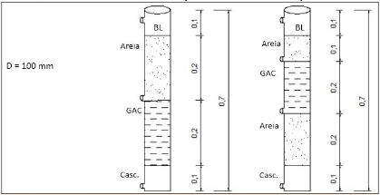

### Metodologia de Análise Estatística Proposta

Nesta pesquisa, será feita uma comparação de diversos fatores entre dois grupos distintos, buscando testar inicialmente a absorbância do Carbendazim pelo filtro bem como o grau de influência da água impura (com microorganismos/DMAE) em relação a água pura, sugerimos utilizar a Análise de Variância (ANOVA).  
Com a Análise de Variância, buscamos quantificar a variabilidade entre grupos distintos de observações, para testar a hipótese de que as médias entre tais grupos são significativamente iguais, desta forma, podemos identificar qual das observações possui maior influência na variável resposta.

Vamos assumir que $\mu_{ij}$ corresponde à média da concentração de Carbedazim na água filtrada no filtro $i$ ($i=1$, para filtro do Tipo I, $i=2$, para filtro do Tipo II) com tipo de água $j$ ($j=1$, para água do Tipo I, $j=2$, para água do tipo II). Dessa forma assume-se como hipótese nula:

$$H_{0}: \mu_{11} = \mu_{12} = \mu_{21} = \mu_{22}$$

Para facilitar o processo de análise, sugere-se que os dados sejam tabulados de forma a listar as observações linha a linha e as variáveis de interesse coluna a coluna.

### Anexos

##### Dicionário de Dados:

$$\small
\begin{array}{llllllllllllll}\hline
\textbf{Código da Variável} && \textbf{Nome}&& \textbf{Descrição}&& \textbf{Unid. de Medida / Escala} &\\ \hline
\text{absorb_cdb} && \text{Absorbância Carbendazim}&& \text{Capacidade de absorção de CBZ em seu comprimento de onda} && -log(\frac{I}{I_0}) &\\
\text{turbidez} && \text{Turbidez}&& \text{Redução de transparência de um meio líquido}&& \text{NTU} &\\
\text{cor} && \text{Cor}&& - && \text{Unidade Hazen - uH} &\\
\text{ph} && \text{pH}&& \text{Indicador de acidez / basicidade em uma solução} && \text{pH}_{[0,14]} & \\
\text{temp_agua} && \text{Temperatura da Água}&& - && \text{Graus Celsius (ºC)} & \\
\text{cod} && \text{Carbono Orgânico Dissolvido} && - && mg/L & \\
\text{e_coli} && \text{Concentração E. Coli}&& - && NMP/100ml & \\
\text{coliformes} && \text{Concentração de coliformes}&& - && NMP/100ml &\\
\text{dna} && \text{Extração de DNA}&&-&&-&\\
\end{array}$$

##### Exemplo de tabulação dos dados:

| Tempo | absorb_cbd | turbidez | cor | ph | temp_agua | cod | e_coli | coliformes | dna |
| --- | --- | --- | --- | --- | --- | --- | --- | --- | --- |
| 11:00 | 1 | 1 | 1 | 1 | 1 | 1 | 1 | 1 | 1 |
| 11:10 | 1 | 1 | 1 | 1 | 1 | 1 | 1 | 1 | 1 |
| 11:20 | 1 | 1 | 1 | 1 | 1 | 1 | 1 | 1 | 1 |